# R Notebook

```r
cars <- read.csv("mode_of_transport.csv")
View(cars)
```

# Structure of the data

```r
str(cars)
```

```
'data.frame':   444 obs. of  9 variables:
 $ Age      : int  28 23 29 28 27 26 28 26 22 27 ...
 $ Gender   : chr  "Male" "Female" "Male" "Female" ...
 $ Engineer : int  0 1 1 1 1 1 1 1 1 1 ...
 $ MBA      : int  0 0 0 1 0 0 0 0 0 0 ...
 $ Work.Exp : int  4 4 7 5 4 4 5 3 1 4 ...
 $ Salary   : num  14.3 8.3 13.4 13.4 13.4 12.3 14.4 10.5 7.5 13.5 ...
 $ Distance : num  3.2 3.3 4.1 4.5 4.6 4.8 5.1 5.1 5.1 5.2 ...
 $ license  : int  0 0 0 0 0 1 0 0 0 0 ...
 $ Transport: chr  "Public Transport" "Public Transport" "Public Transport" "Public Transport" ...
```

Variables like Engineer, MBA, license contains category values. So, we need to convert them into factors.

```r
cars$Engineer = as.factor(cars$Engineer)
cars$MBA = as.factor(cars$MBA)
cars$license = as.factor(cars$license)
cars$Gender = as.factor(cars$Gender)
cars$Transport = as.factor(cars$Transport)
```

# Summary of dataset

```r
summary(cars)
```

```
      Age           Gender    Engineer MBA        Work.Exp        Salary
 Min.   :18.00   Female:128   0:109    0:332   Min.   : 0.0   Min.   : 6.50
 1st Qu.:25.00   Male  :316   1:335    1:112   1st Qu.: 3.0   1st Qu.: 9.80
 Median :27.00                                 Median : 5.0   Median :13.60
 Mean   :27.75                                 Mean   : 6.3   Mean   :16.24
 3rd Qu.:30.00                                 3rd Qu.: 8.0   3rd Qu.:15.72
 Max.   :43.00                                 Max.   :24.0   Max.   :57.00
    Distance     license             Transport
 Min.   : 3.20   0:340   Private Transport:144
 1st Qu.: 8.80   1:104   Public Transport :300
 Median :11.00
 Mean   :11.32
 3rd Qu.:13.43
 Max.   :23.40
```

Here, the minimum age is 18, maximum age is 43 and average age is 27. We conclude that the majority is of males of approximately 70-77%. Here, there are more Engineers than MBA’s. And, the most common mode of transport is public transportation.

# Visual Analysis of data

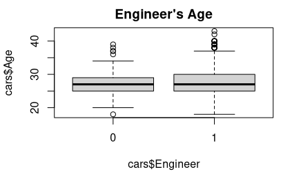

```r
boxplot(cars$Age ~ cars$Engineer, main="Engineer's Age")
```

```r
boxplot(cars$Age ~ cars$MBA, main="MBA's Age")
```

[output not shown]

There’s no much difference in the age of Engineers and MBA’s.

Let’s find differences in the average salary for two professions.

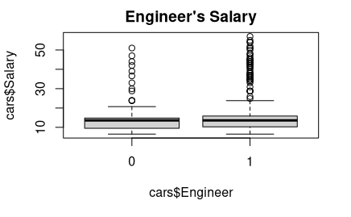

```r
boxplot(cars$Salary ~ cars$Engineer, main="Engineer's Salary")
```

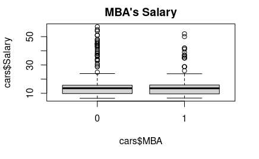

```r
boxplot(cars$Salary ~ cars$MBA, main="MBA's Salary")
```

There’s isn’t any major difference in the salary.

Let’s see the Work Exp column

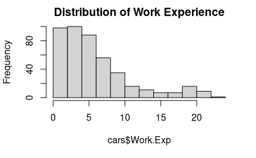

```r
hist(cars$Work.Exp, main="Distribution of Work Experience")
```

This column is right skewed, this is expected as there would be more juniors then seniors in any firm.

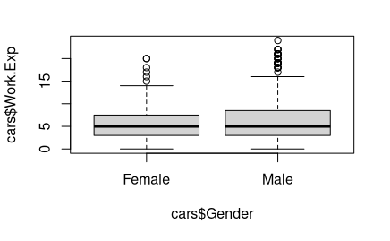

```r
boxplot(cars$Work.Exp ~ cars$Gender)
```

```r
table(cars$license, cars$Transport)
```

```
    Private Transport Public Transport
  0                73              267
  1                71               33
```

The table clearly shows that those who don’t have license uses public transport more.

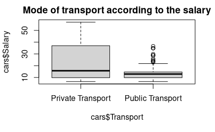

```r
boxplot(cars$Salary ~ cars$Transport, main="Mode of transport according to the salary")
```

Plot clearly shows that as the salary increases the number of individuals with private transport also increases.

Let’s see if the age and work experience can be usage of private transport increases

```r
cor(cars$Age, cars$Work.Exp)
```

```
[1] 0.9322364
```

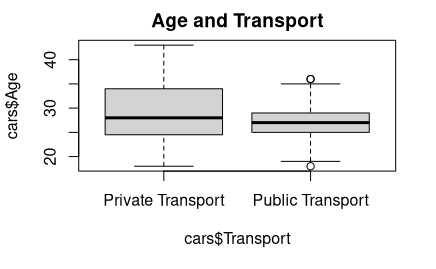

```r
boxplot(cars$Age ~ cars$Transport, main="Age and Transport")
```

The plot clearly explains that the higher age prefers private transport.

Let’s see with the increase in distance would the employees prefer private or public transport.

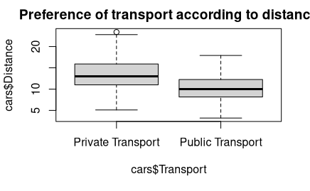

```r
boxplot(cars$Distance ~ cars$Transport, main="Preference of transport according to distance")
```

In this plot the pattern shows that for longer distance private transport is the preference of employees.

Let’s see whether female employees prefer private or public transport

```r
table(cars$Gender, cars$Transport)
```

```
         Private Transport Public Transport
  Female                51               77
  Male                  93              223
```

From the above data it is visible that more females prefers Public Transport.

Only 40% female uses private transport and only 30% male uses private transport.